# 6. Frequency - Hurdle - NB

```r
library(MASS)
library(lmtest)
library(pscl)
library(xgboost)
library(ggplot2)
library(caret)
```

```r
source('/home/kate/code/Utils/MyFunctions.R')
```

```r
ModelsDir <- '/home/kate/Research/Property/Models/'
UseSavedIfExists <- TRUE
```

```r
training_data <- read.csv("/home/kate/Research/Property/Data/property_wcf_training.csv", header=TRUE)
testing_data <- read.csv("/home/kate/Research/Property/Data/property_wcf_testing.csv", header=TRUE)
```

NB work with factors and because some numerical columns are factors (ordered) I convert them in factors explicitly. I may need to do this for some other columns which are Yes/No.

```r
training_data$appl_fail_3_blk <- as.factor( training_data$appl_fail_3_blk )
training_data$fixture_leak_3_blk <- as.factor( training_data$fixture_leak_3_blk )
training_data$pipe_froze_3_blk <- as.factor( training_data$pipe_froze_3_blk )
training_data$plumb_leak_3_blk <- as.factor( training_data$plumb_leak_3_blk )
training_data$rep_cost_3_blk <- as.factor( training_data$rep_cost_3_blk )
training_data$ustructure_fail_3_blk <- as.factor( training_data$ustructure_fail_3_blk )
training_data$waterh_fail_3_blk <- as.factor( training_data$waterh_fail_3_blk )
```

```r
testing_data$appl_fail_3_blk <- as.factor( testing_data$appl_fail_3_blk )
testing_data$fixture_leak_3_blk <- as.factor( testing_data$fixture_leak_3_blk )
testing_data$pipe_froze_3_blk <- as.factor( testing_data$pipe_froze_3_blk )
testing_data$plumb_leak_3_blk <- as.factor( testing_data$plumb_leak_3_blk )
testing_data$rep_cost_3_blk <- as.factor( testing_data$rep_cost_3_blk )
testing_data$ustructure_fail_3_blk <- as.factor( testing_data$ustructure_fail_3_blk )
testing_data$waterh_fail_3_blk <- as.factor( testing_data$waterh_fail_3_blk )
```

```r
max_yearbuilt <- max(training_data$yearbuilt)
max_sqft <- max(training_data$sqft)
max_water_risk_3_blk <- max(training_data$water_risk_3_blk)
max_water_risk_fre_3_blk <- max(training_data$water_risk_fre_3_blk)
max_water_risk_sev_3_blk <- max(training_data$water_risk_sev_3_blk)
```

```r
training_data$log_norm_yearbult <- log(training_data$yearbuilt/max_yearbuilt)
training_data$log_norm_sqft <- log(training_data$sqft/max_sqft)
training_data$log_norm_water_risk_3_blk <- log(training_data$water_risk_3_blk/max_water_risk_3_blk)
training_data$log_norm_water_risk_fre_3_blk <- log(training_data$water_risk_fre_3_blk/max_water_risk_fre_3_blk)
training_data$log_norm_water_risk_sev_3_blk <- log(training_data$sqft/max_water_risk_sev_3_blk)
```

```r
testing_data$log_norm_yearbult <- log(testing_data$yearbuilt/max_yearbuilt)
testing_data$log_norm_sqft <- log(testing_data$sqft/max_sqft)
testing_data$log_norm_water_risk_3_blk <- log(testing_data$water_risk_3_blk/max_water_risk_3_blk)
testing_data$log_norm_water_risk_fre_3_blk <- log(testing_data$water_risk_fre_3_blk/max_water_risk_fre_3_blk)
testing_data$log_norm_water_risk_sev_3_blk <- log(testing_data$sqft/max_water_risk_sev_3_blk)
```

```r
training_data$stories <- as.factor(training_data$stories)
training_data$units <- as.factor(training_data$units)
training_data$secondaryresidence <- as.factor(training_data$secondaryresidence)
training_data$sprinklersystem <- as.factor(training_data$sprinklersystem)
training_data$firealarmtype <- as.factor(training_data$firealarmtype)
training_data$waterdetectiondevice <- as.factor(training_data$waterdetectiondevice)
training_data$propertymanager <- as.factor(training_data$propertymanager)
training_data$cova_deductible <- as.factor(training_data$cova_deductible)
training_data$cova_limit       <- as.factor(training_data$cova_limit      )
training_data$waterded <- as.factor(training_data$waterded)
training_data$protectionclass <- as.factor(training_data$protectionclass)
training_data$fire_risk_model_score <- as.factor(training_data$fire_risk_model_score)
training_data$ordinanceorlawpct <- as.factor(training_data$ordinanceorlawpct)
training_data$functionalreplacementcost <- as.factor(training_data$functionalreplacementcost)
training_data$homegardcreditind <- as.factor(training_data$homegardcreditind)
training_data$landlordind <- as.factor(training_data$landlordind)
training_data$rentersinsurance <- as.factor(training_data$rentersinsurance)
training_data$burglaryalarmtype <- as.factor(training_data$burglaryalarmtype)
training_data$propertymanager <- as.factor(training_data$propertymanager)
```

```r
testing_data$stories <- as.factor(testing_data$stories)
testing_data$units <- as.factor(testing_data$units)
testing_data$secondaryresidence <- as.factor(testing_data$secondaryresidence)
testing_data$sprinklersystem <- as.factor(testing_data$sprinklersystem)
testing_data$firealarmtype <- as.factor(testing_data$firealarmtype)
testing_data$waterdetectiondevice <- as.factor(testing_data$waterdetectiondevice)
testing_data$propertymanager <- as.factor(testing_data$propertymanager)
testing_data$cova_deductible <- as.factor(testing_data$cova_deductible)
testing_data$cova_limit       <- as.factor(testing_data$cova_limit      )
testing_data$waterded <- as.factor(testing_data$waterded)
testing_data$protectionclass <- as.factor(testing_data$protectionclass)
testing_data$fire_risk_model_score <- as.factor(testing_data$fire_risk_model_score)
testing_data$ordinanceorlawpct <- as.factor(testing_data$ordinanceorlawpct)
testing_data$functionalreplacementcost <- as.factor(testing_data$functionalreplacementcost)
testing_data$homegardcreditind <- as.factor(testing_data$homegardcreditind)
testing_data$landlordind <- as.factor(testing_data$landlordind)
testing_data$rentersinsurance <- as.factor(testing_data$rentersinsurance)
testing_data$burglaryalarmtype <- as.factor(testing_data$burglaryalarmtype)
testing_data$propertymanager <- as.factor(testing_data$propertymanager)
```

```r
#unique numclaims values
numclaims <- unique(training_data$cova_ic_nc_water)
```

## Modeling

```r
formula_sign <-  cova_ic_nc_water ~
log_norm_yearbult +
log_norm_sqft +
#stories +
#roofcd +
#units +
#waterded +
#protectionclass +
#constructioncd +
#sprinklersystem +
#landlordind +
#firealarmtype +
cova_limit +
log_norm_water_risk_3_blk +
log_norm_water_risk_fre_3_blk +
appl_fail_3_blk +
fixture_leak_3_blk +
#pipe_froze_3_blk +
plumb_leak_3_blk +
waterh_fail_3_blk |
log_norm_yearbult +
log_norm_sqft +
stories +
roofcd +
units +
waterded +
protectionclass +
constructioncd +
sprinklersystem +
landlordind +
firealarmtype +
cova_limit +
log_norm_water_risk_3_blk +
log_norm_water_risk_fre_3_blk +
appl_fail_3_blk +
fixture_leak_3_blk +
pipe_froze_3_blk +
plumb_leak_3_blk +
waterh_fail_3_blk
UseSavedIfExists <- FALSE
```

```r
ModelFile <- paste(ModelsDir,"hurdlenb_sign.rds",sep="")
if(file.exists(ModelFile) && UseSavedIfExists){
    hurdlenb_sign <- readRDS(ModelFile)
    } else {
    hurdlenb_sign <- hurdle(formula_sign,  data = training_data,  offset=log_ecy,dist ="negbin",zero.dist = "negbin",link= "logit")
    saveRDS(hurdlenb_sign, ModelFile)
    }
summary(hurdlenb_sign)
```

```
Call:
hurdle(formula = formula_sign, data = training_data, offset = log_ecy,
    dist = "negbin", zero.dist = "negbin", link = "logit")

Pearson residuals:
     Min       1Q   Median       3Q      Max
-0.20491 -0.11816 -0.09754 -0.07601 54.81541

Count model coefficients (truncated negbin with log link):
                                Estimate Std. Error z value Pr(>|z|)
(Intercept)                    -15.39766 2274.07212  -0.007 0.994598
log_norm_yearbult                8.37934    8.82994   0.949 0.342636
log_norm_sqft                    0.21383    0.32996   0.648 0.516953
cova_limit200000                -1.19337    0.49989  -2.387 0.016975 *
cova_limit300000                -0.36550    0.38941  -0.939 0.347935
cova_limit400000                -0.34984    0.41053  -0.852 0.394123
cova_limit500000                -0.16992    0.45527  -0.373 0.708981
cova_limit600000                -0.35003    0.51050  -0.686 0.492931
cova_limit700000                 0.07342    0.55652   0.132 0.895046
cova_limit800000                -0.55717    0.69396  -0.803 0.422041
cova_limit900000                -0.12775    0.70805  -0.180 0.856820
cova_limit1000000                0.27457    0.76018   0.361 0.717953
cova_limit1200000                0.13837    0.82679   0.167 0.867083
cova_limit1300000                0.06198    0.85706   0.072 0.942351
log_norm_water_risk_3_blk       -0.33308    0.39183  -0.850 0.395296
log_norm_water_risk_fre_3_blk    0.57943    0.38169   1.518 0.128999
appl_fail_3_blk1                -1.89063    0.59800  -3.162 0.001569 **
appl_fail_3_blk2                -1.33125    0.65534  -2.031 0.042217 *
appl_fail_3_blk3                -1.33491    0.64162  -2.081 0.037477 *
appl_fail_3_blk4                -1.60169    0.58509  -2.737 0.006191 **
appl_fail_3_blk5                -1.93621    0.57197  -3.385 0.000711 ***
fixture_leak_3_blk1             -0.51052    0.29719  -1.718 0.085828 .
fixture_leak_3_blk2             -0.28594    0.24957  -1.146 0.251900
fixture_leak_3_blk3             -0.34919    0.28399  -1.230 0.218846
fixture_leak_3_blk4             -0.60972    0.43584  -1.399 0.161829
fixture_leak_3_blk5             -0.63172    1.08464  -0.582 0.560282
plumb_leak_3_blk1               15.53947 2274.05525   0.007 0.994548
plumb_leak_3_blk2               14.03767 2274.05519   0.006 0.995075
plumb_leak_3_blk3               15.26909 2274.05537   0.007 0.994643
plumb_leak_3_blk4               15.78141 2274.05524   0.007 0.994463
```

[output cut: 74 more lines]

```
plumb_leak_3_blk3              0.118195   0.235366   0.502 0.615544
plumb_leak_3_blk4              0.332433   0.226751   1.466 0.142629
plumb_leak_3_blk5              0.600195   0.233199   2.574 0.010060 *
waterh_fail_3_blk1             0.298249   0.072077   4.138 3.50e-05 ***
waterh_fail_3_blk2             0.174581   0.042633   4.095 4.22e-05 ***
waterh_fail_3_blk3             0.031888   0.064998   0.491 0.623711
waterh_fail_3_blk4             0.122794   0.100393   1.223 0.221279
waterh_fail_3_blk5             0.126055   0.146135   0.863 0.388364
Log(theta)                    -4.354794   0.236174 -18.439  < 2e-16 ***
---
Signif. codes:  0 '***' 0.001 '**' 0.01 '*' 0.05 '.' 0.1 ' ' 1

Theta: count = 1.1303, zero = 0.0128
Number of iterations in BFGS optimization: 163
Log-likelihood: -5.322e+04 on 111 Df
```

Hurdle NB model is even more sensitive to the predictors then Hurdle Poisson or Zero Inflated. The predictors above are only I was able to add to get non NAN resullts.

### Rootograms for Assessing Goodness of Fit of Probability...

```r
library(countreg)
```

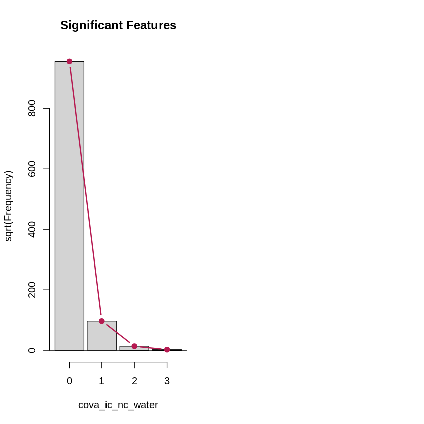

```r
par(mfrow = c(1, 2))
rootogram(hurdlenb_sign,max = max(numclaims),main="Significant Features",style="hanging")
```

## Predicting Number of claims

I use XGB to predict the final result based on probabilities of number claims in each row.

```r
param0 <- list(
  "objective"  = "count:poisson"
  , "eval_metric" = "poisson-nloglik"
)
```

```r
#Adding  predicted probability values
#to training and testing dataset for each numclaims
#as separate column



training_sign <- predict(hurdlenb_sign, training_data, type='prob')
testing_sign <- predict(hurdlenb_sign, testing_data, type='prob')

for(unique_value in numclaims){


training_data[paste("hurdlenb_sign", unique_value, sep = ".")] <- training_sign[,as.numeric(unique_value)+1]
testing_data[paste("hurdlenb_sign", unique_value, sep = ".")] <- testing_sign[,as.numeric(unique_value)+1]

}
```

```r
#Features with probabilities listed by model

HNB_sign_features <- list();

i <- 1
for(unique_value in numclaims){
    HNB_sign_features[[i]] <- paste("hurdlenb_sign", unique_value, sep = ".")

    i <- i + 1
}
```

```r
xgHNB_sign_training = xgb.DMatrix(as.matrix(training_data[,unlist(HNB_sign_features)]), label = training_data$cova_ic_nc_water)
setinfo(xgHNB_sign_training, "base_margin", log(training_data$ecy))

xgHNB_sign_testing = xgb.DMatrix(as.matrix(testing_data[,unlist(HNB_sign_features)]), label = testing_data$cova_ic_nc_water)
setinfo(xgHNB_sign_testing, "base_margin", log(testing_data$ecy))
```

TRUE

TRUE

```r
xgb = xgb.train(
  nrounds = 10000
  , params = param0
  , data = xgHNB_sign_training
)
training_data$hurdlenb_sign = predict(xgb, xgHNB_sign_training)
testing_data$hurdlenb_sign = predict(xgb, xgHNB_sign_testing)
```

As an accuracy measure I use Normalized Weighted Gini:

```r
Testing_Gini <- data.frame ("Significant Only" = NormalizedWeightedGini(testing_data$cova_ic_nc_water,testing_data$hurdlenb_sign,testing_data$ecy)
                   )
Testing_Gini
```

A data.frame: 1 × 1

| Significant.Only <dbl> |
| --- |
| 0.226707 |

### K Fold Validation

TBD Does not work with Caret very strightforward and my manual approach is wrong somewhere

## Conclusion

- Normalization is needed to make the model work. I need to include normalized log columns in the datasets when it's extracted.
- I convert all other columns into factors but not sure if it's needed.
- I can use very small set of predictors in this model. With adding any other I get NAN in theta for the NB part.
- Almost nothing significant for the NB part
- Normalized Weighted Gini is the worse so far.
- Is Logistic model (0/1) would be more precise?